# CABA_cluster

Sol Represa

13/11/2019

Este trabajo tiene como objetivo identificar las condiciones meteorológicas que se presentan cuando suceden eventos extremos.

Los datos fueron recolectados por las estaciones de monitoreo contínuo de calidad de aire de la *Agencia de Protección Ambiental* de la Ciudad Autónoma de Buenos Aires (Argentina).

La base de datos corresponde al período comprendido entre **2009-10-01 14:00:00** hasta **2017-10-01 00:00:00**, contándose con un total de 70115 registros de cada contaminante por estación. Los contaminantes monitoreados son: CO (ppm) , NO<sub>2</sub> (ppb) y PM<sub>10</sub> ($\mu g.m^{-3}$).

*Tabla 1. Total datos faltantes por estación*

| ESTACION | NA | % |
| --- | --- | --- |
| CENTENARIO | 63224 | 30.1 |
| CORDOBA | 73801 | 35.1 |
| LA BOCA | 50619 | 24.1 |

*Tabla 2. Número de datos faltantes y su porcentaje por contaminantes*

| VARIABLE | CENTENARIO | CORDOBA | LA BOCA | CENTENARIO | CORDOBA | LA BOCA |
| --- | --- | --- | --- | --- | --- | --- |
| CO | 23634 | 19343 | 14554 | 33.7 % | 27.6 % | 20.8 % |
| NO<sub>2</sub> | 15648 | 24864 | 14789 | 22.3 % | 35.5 % | 21.1 % |
| PM<sub>10</sub> | 23942 | 29594 | 21276 | 34.1 % | 42.2 % | 30.3 % |

```
##         date1         date2 CO_CENTENARIO    CO_CORDOBA    CO_LA_BOCA
##     "POSIXct"      "POSIXt"     "numeric"     "numeric"     "numeric"
```

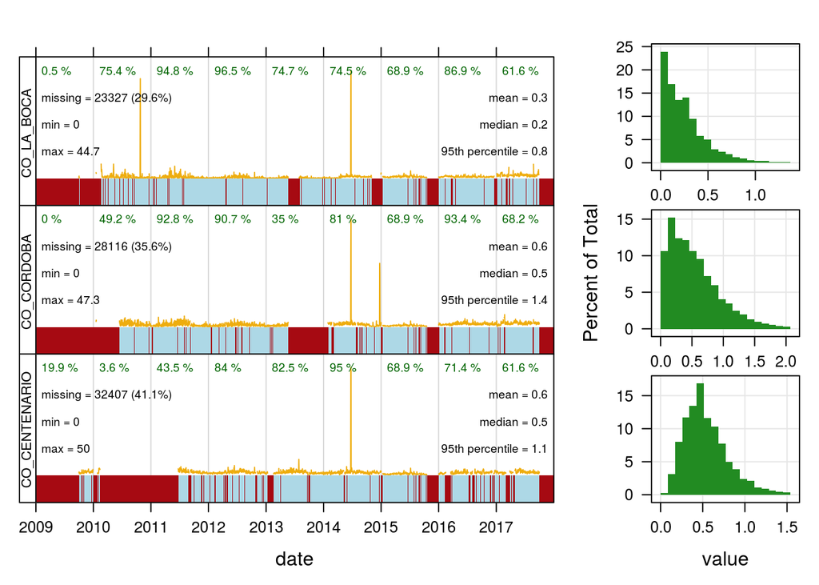

```
##          date1          date2 NO2_CENTENARIO    NO2_CORDOBA    NO2_LA_BOCA
##      "POSIXct"       "POSIXt"      "integer"      "integer"      "integer"
```

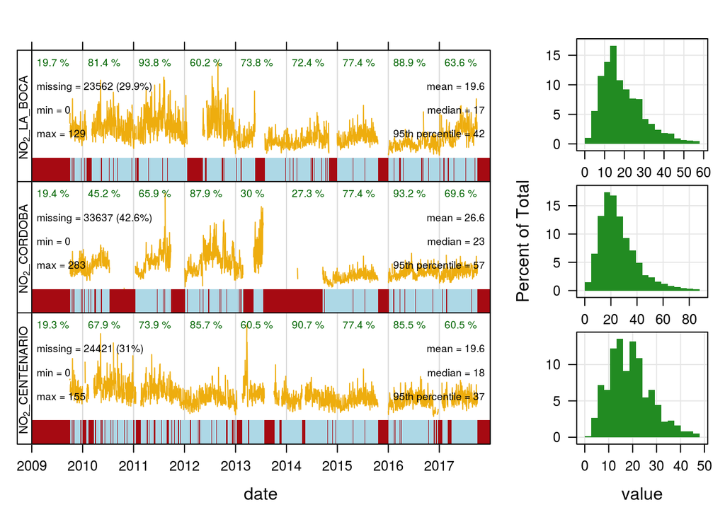

```
##           date1           date2 PM10_CENTENARIO    PM10_CORDOBA
##       "POSIXct"        "POSIXt"       "integer"       "integer"
##    PM10_LA_BOCA
##       "integer"
```

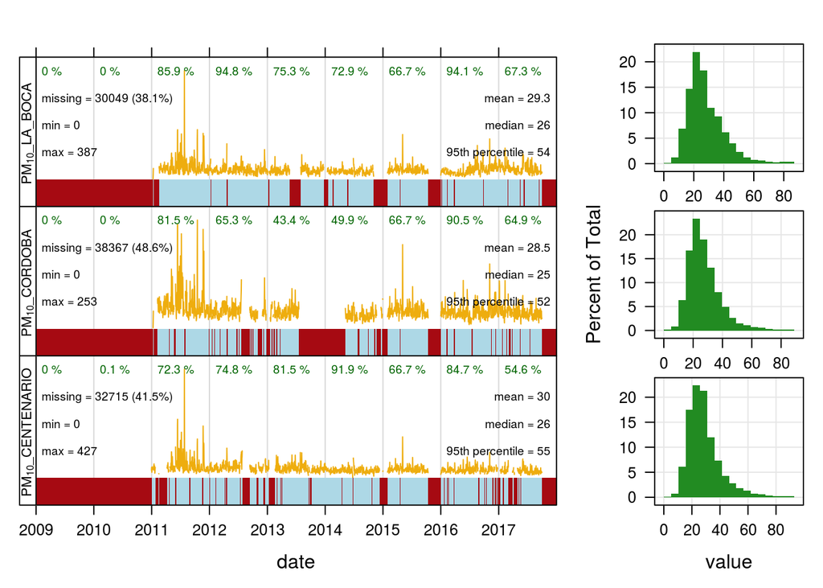

Estadisticos descritivos por contaminantes y estación:

```
## # A tibble: 9 x 7
## # Groups:   pollutant [3]
##   pollutant site         min median   mean   max     sd
##   <chr>     <chr>      <dbl>  <dbl>  <dbl> <dbl>  <dbl>
## 1 CO        CENTENARIO     0   0.5   0.572  50.0  0.921
## 2 CO        CORDOBA        0   0.47  0.590  47.3  1.13
## 3 CO        LA_BOCA        0   0.21  0.300  44.7  1.00
## 4 NO2       CENTENARIO     0  18    19.6   155    9.66
## 5 NO2       CORDOBA        0  23    26.6   283   16.8
## 6 NO2       LA_BOCA        0  17    19.6   129   11.8
## 7 PM10      CENTENARIO     0  26    30.0   427   17.9
## 8 PM10      CORDOBA        0  25    28.5   253   16.2
## 9 PM10      LA_BOCA        0  26    29.3   387   17.2
```

Comportamiento de la serie de tiempo de PM[10] para todo el período:

Serie de tiempo de los valores máximos diarios:

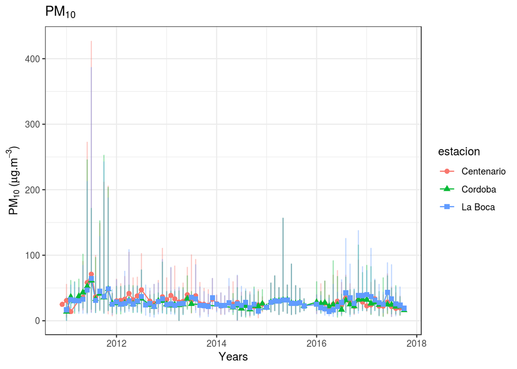

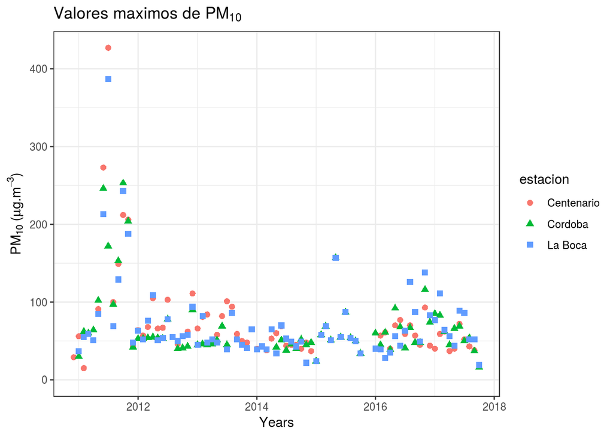

Durante 2011 fue la erupación del volcán Puyehue. Descarto este año.

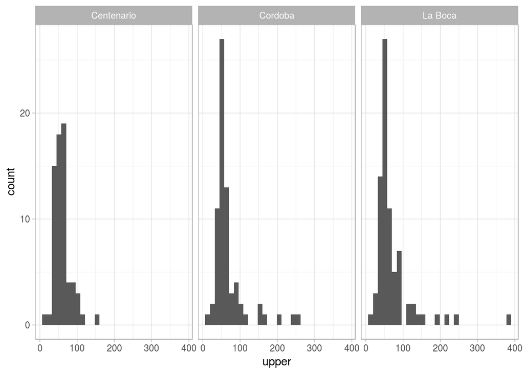

Filtramos en función del percentil 90, el cual para cada estación será:

```
## # A tibble: 3 x 2
##   estacion     p90
##   <fct>      <dbl>
## 1 Centenario  89.4
## 2 Cordoba    103.
## 3 La Boca    115.
```

### MERGE con datos del SMN

**Los datos meteo em hora ¿los pasamos a día? ¿se toman las medias?**